# Explore gene filtering strategy

Results for SCPCS000104: SCPCL000121

Stephanie J. Spielman

2025-07-10

The goal of this notebook is to assess `SingleR` results inferred with two different models constructed from NBAtlas:

- A model where ribosomal and mitochondrial genes were filtered out of the reference before building the model
  - This means those genes will not come up as marker genes for cell type annotation
- A models where no genes are filtered out
  - There means there is potential for those genes to come up as marker genes for cell type annotation

This notebook compares inferences made with either model to determine whether this filtering makes an empirical difference. It also compares marker genes in the underlying models directly to get a sense of how much the filtering influenced model training.

## Setup

```r
options(readr.show_col_types = FALSE)

suppressWarnings({
  suppressPackageStartupMessages({
    library(ggplot2)
    library(patchwork)
    library(SingleCellExperiment)
  })
})


theme_set(theme_bw())

# Define color ramp for shared use in the heatmaps
heatmap_col_fun <- circlize::colorRamp2(c(0, 1), colors = c("white", "darkslateblue"))
# Set heatmap padding option
ComplexHeatmap::ht_opt(TITLE_PADDING = grid::unit(0.6, "in"))
```

### Paths

```r
# The base path for the OpenScPCA repository, found by its (hidden) .git directory
repository_base <- rprojroot::find_root(rprojroot::is_git_root)

module_dir <- file.path(repository_base, "analyses", "cell-type-neuroblastoma-04")
results_dir <- file.path(module_dir, "results")
filtered_results_dir <- file.path(results_dir, "singler-test_filter-genes-TRUE")
unfiltered_results_dir <- file.path(results_dir, "singler-test_filter-genes-FALSE")
data_dir <- file.path(repository_base, "data", "current", "SCPCP000004")
```

```r
# SingleR results
filtered_singler_file <- file.path(
  filtered_results_dir,
  params$sample_id,
  glue::glue("{params$library_id}_singler-results.rds")
)

unfiltered_singler_file <- file.path(
  unfiltered_results_dir,
  params$sample_id,
  glue::glue("{params$library_id}_singler-results.rds")
)

# SCE file
sce_file <- file.path(
  data_dir,
  params$sample_id,
  glue::glue("{params$library_id}_processed.rds")
)

# broad consensus cell type groups
validation_url <- "https://raw.githubusercontent.com/AlexsLemonade/OpenScPCA-analysis/refs/heads/main/analyses/cell-type-consensus/references/consensus-validation-groups.tsv"
```

### Functions

```r
# Source Jaccard and heatmap utilities functions:
source(file.path(module_dir, "exploratory-notebooks", "jaccard-utils.R"))
```

### Prepare input data

Read SCE object and define data frame of UMAP coordinates.

```r
validation_df <- readr::read_tsv(validation_url) |>
  dplyr::select(consensus_annotation, validation_group_annotation)

sce <- readRDS(sce_file)

sce_df <- sce |>
  scuttle::makePerCellDF(
    use.coldata = c("barcodes", "consensus_celltype_annotation"),
    use.dimred = c("UMAP")
  ) |>
  dplyr::rename(
    UMAP1 = UMAP.1,
    UMAP2 = UMAP.2,
    consensus_annotation = consensus_celltype_annotation
  )
```

Read SingleR result objects:

```r
singler_results_filtered <- readr::read_rds(filtered_singler_file)
singler_results_unfiltered <- readr::read_rds(unfiltered_singler_file)
```

Read SingleR models:

```r
model_filtered <- readRDS(
  file.path(
    module_dir,
    "scratch",
    "singler-model_nbatlas_filter-genes-TRUE.rds"
  )
)
model_unfiltered <- readRDS(
  file.path(
    module_dir,
    "scratch",
    "singler-model_nbatlas_filter-genes-FALSE.rds"
  )
)
```

Join and prepare data for use:

```r
singler_df <- data.frame(
  barcodes = rownames(singler_results_filtered),
  "singler_label_filtered" = as.data.frame(singler_results_filtered)$pruned.labels,
  "singler_label_unfiltered" = as.data.frame(singler_results_unfiltered)$pruned.labels
) |>
  dplyr::left_join(sce_df, by = "barcodes") |>
  dplyr::left_join(validation_df, by = "consensus_annotation") |>
  dplyr::mutate(
    validation_group_annotation = ifelse(
      is.na(validation_group_annotation),
      "unknown",
      validation_group_annotation
    )
  )
```

## Filtered vs unfiltered models

### UMAP

We’ll display their annotations side-by-side as a UMAP. Cells labeled `NA` are those that SingleR could not confidently label.

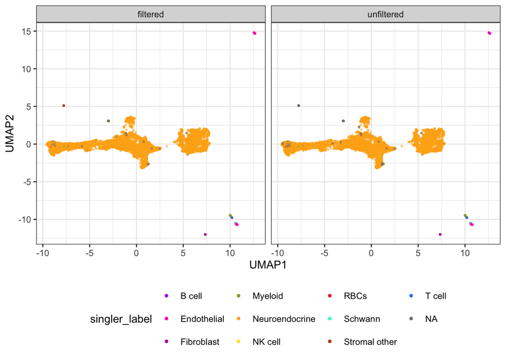

```r
# colors adapted from:
# https://github.com/AlexsLemonade/scpca-paper-figures/blob/a457408323495b6ecee0c63ccdd74b41e88ab703/palettes/validation-group-palette.tsv
nbatlas_colors <- c(
  "B cell" = "#AA0DFE",
  "Endothelial" = "#FC1CBF",
  "Fibroblast" = "#B10DA1",
  "Myeloid" = "#90AD1C",
  "Neuroendocrine" = "#FEAF16",
  "Neuroendocrine-tumor" = "#B17A0F",
  "NK cell" = "#FBE426",
  "pDC" = "#16FF32",
  "Plasma" = "#782AB6",
  "RBCs" = "#F6222E",
  "Schwann" = "#1CFFCE",
  "Stromal other" = "#C4451C",
  "T cell" = "#3283FE"
)
singler_long_df <- singler_df |>
  tidyr::pivot_longer(
    contains("singler_label"),
    names_to = "model",
    values_to = "singler_label"
  ) |>
  dplyr::mutate(model = stringr::str_remove(model, "singler_label_"))

ggplot(singler_long_df) +
  aes(x = UMAP1, y = UMAP2, color = singler_label) +
  geom_point(size = 0.5, alpha = 0.5) +
  scale_color_manual(values = nbatlas_colors) +
  facet_wrap(vars(model)) +
  theme(legend.position = "bottom") +
  guides(color = guide_legend(override.aes = list(size = 1, alpha = 1)))
```

### Heatmap

We’ll display the relationship between annotations as a heatmap colored by Jaccard similarity:

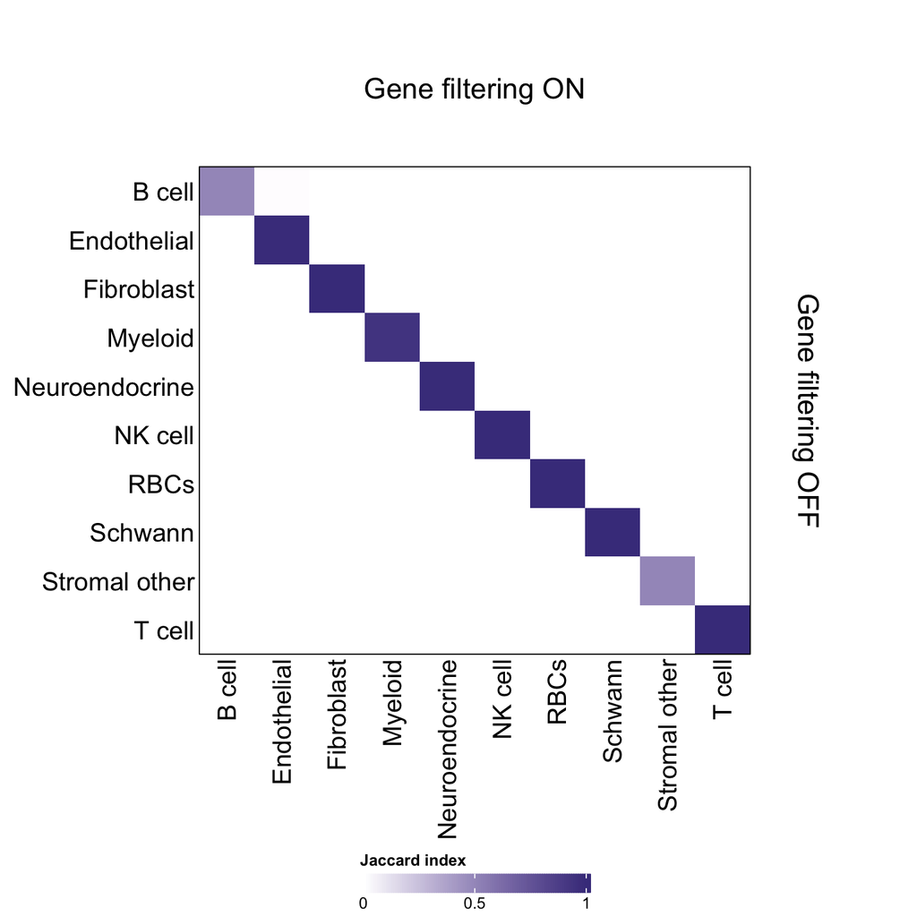

```r
make_jaccard_heatmap(
  singler_df,
  "singler_label_filtered",
  "singler_label_unfiltered",
  "Gene filtering ON",
  "Gene filtering OFF"
)
```

### Confusion matrix

Below we display the confusion matrix and associated statistics comparing these annotations. Annotations from the unfiltered genes model are shown as “Reference,” and annotations from the filtered genes model are shown as “Prediction.”

Note that some cell type names have been abbreviated in this output to make it more clearly visible:

- Endothelial –> Endo
- Fibroblasts –> Fibro
- Neuroendocrine –> NE
- Stromal other –> stromal

```r
singler_long_df <- singler_long_df |>
  # shorten labels
  dplyr::mutate(
    short_label = dplyr::case_when(
      singler_label == "Endothelial" ~ "Endo",
      singler_label == "Fibroblast" ~ "Fibro",
      singler_label == "Neuroendocrine" ~ "NE",
      singler_label == "Stromal other" ~ "stromal",
      .default = singler_label
    )
  )

caret::confusionMatrix(
  factor(singler_long_df$short_label[singler_long_df$model == "filtered"]), # data
  factor(singler_long_df$short_label[singler_long_df$model == "unfiltered"]), # reference
  mode = "sens_spec"
)
```

```
Confusion Matrix and Statistics

          Reference
Prediction B cell Endo Fibro Myeloid   NE NK cell RBCs Schwann stromal T cell
   B cell       1    0     0       0    0       0    0       0       0      0
   Endo         1  123     0       0    0       0    0       0       0      0
   Fibro        0    0    12       0    0       0    0       0       0      0
   Myeloid      0    0     0      32    0       0    0       0       0      0
   NE           0    0     0       0 6522       0    0       0       0      0
   NK cell      0    0     0       0    0       3    0       0       0      0
   RBCs         0    0     0       0    0       0    8       0       0      0
   Schwann      0    0     0       0    0       0    0       1       0      0
   stromal      0    0     0       0    0       0    0       0       3      0
   T cell       0    0     0       0    0       0    0       0       0      9

Overall Statistics

               Accuracy : 0.9999
                 95% CI : (0.9992, 1)
    No Information Rate : 0.9713
    P-Value [Acc > NIR] : < 2.2e-16

                  Kappa : 0.9974

 Mcnemar's Test P-Value : NA

Statistics by Class:

                     Class: B cell Class: Endo Class: Fibro Class: Myeloid
Sensitivity              0.5000000     1.00000     1.000000       1.000000
Specificity              1.0000000     0.99985     1.000000       1.000000
Pos Pred Value           1.0000000     0.99194     1.000000       1.000000
Neg Pred Value           0.9998511     1.00000     1.000000       1.000000
Prevalence               0.0002978     0.01832     0.001787       0.004765
Detection Rate           0.0001489     0.01832     0.001787       0.004765
Detection Prevalence     0.0001489     0.01847     0.001787       0.004765
Balanced Accuracy        0.7500000     0.99992     1.000000       1.000000
                     Class: NE Class: NK cell Class: RBCs Class: Schwann
Sensitivity             1.0000      1.0000000    1.000000      1.0000000
Specificity             1.0000      1.0000000    1.000000      1.0000000
Pos Pred Value          1.0000      1.0000000    1.000000      1.0000000
Neg Pred Value          1.0000      1.0000000    1.000000      1.0000000
Prevalence              0.9713      0.0004468    0.001191      0.0001489
Detection Rate          0.9713      0.0004468    0.001191      0.0001489
Detection Prevalence    0.9713      0.0004468    0.001191      0.0001489
Balanced Accuracy       1.0000      1.0000000    1.000000      1.0000000
                     Class: stromal Class: T cell
Sensitivity               1.0000000       1.00000
Specificity               1.0000000       1.00000
Pos Pred Value            1.0000000       1.00000
Neg Pred Value            1.0000000       1.00000
Prevalence                0.0004468       0.00134
Detection Rate            0.0004468       0.00134
Detection Prevalence      0.0004468       0.00134
Balanced Accuracy         1.0000000       1.00000
```

### Unlabeled cells

We can also ask whether each model was able to label cells successfully, or whether more cells were ambiguous (aka `pruned.label` is `NA`) in one model or the other.

How many cells were `NA` in both models?

```r
na_cells <- singler_df |>
  dplyr::filter(is.na(singler_label_filtered), is.na(singler_label_unfiltered)) |>
  dplyr::pull(barcodes)

length(na_cells)
```

```
[1] 71
```

#### Unlabeled cells in the filtered genes model

Excluding cells which neither model labeled…

- How many cells did the filtered genes model uniquely fail to label?
- What did the unfiltered genes model label those cells?

```r
# if na in separated, what was it in combined?
unlabeled_in_filtered <- singler_results_filtered |>
  as.data.frame() |>
  tibble::rownames_to_column("barcodes") |>
  dplyr::filter(is.na(pruned.labels), !(barcodes %in% na_cells)) |>
  dplyr::pull(barcodes)
length(unlabeled_in_filtered)
```

```
[1] 12
```

```r
singler_df |>
  dplyr::filter(barcodes %in% unlabeled_in_filtered) |>
  dplyr::count(singler_label_unfiltered) |>
  dplyr::arrange(desc(n))
```

| singler_label_unfiltered | n |
| --- | --- |
| Neuroendocrine | 12 |

#### Unlabeled cells in the unfiltered model

Excluding cells which neither model labeled…

- How many cells did the unfiltered model uniquely fail to label?
- What did the filtered model label those cells?

```r
# if na in unfiltered, what was it in separated?
unlabeled_in_unfiltered <- singler_results_unfiltered |>
  as.data.frame() |>
  tibble::rownames_to_column("barcodes") |>
  dplyr::filter(is.na(pruned.labels), !(barcodes %in% na_cells)) |>
  dplyr::pull(barcodes)
length(unlabeled_in_unfiltered)
```

```
[1] 18
```

```r
singler_df |>
  dplyr::filter(barcodes %in% unlabeled_in_unfiltered) |>
  dplyr::count(singler_label_filtered) |>
  dplyr::arrange(desc(n))
```

| singler_label_filtered | n |
| --- | --- |
| Neuroendocrine | 13 |
| Stromal other | 3 |
| Myeloid | 2 |

## Comparison with consensus cell type annotations

In this section, we compare filtered & unfiltered annotations to the consensus cell type labels. In these comparisons, we consider the broader validation groupings for consensus cell types in order to keep plots manageable and more easily interpreted.

### Heatmap: Filtered vs. consensus annotations

This heatmap compares annotations between `SingleR` inference using the filtered reference and consensus cell types.

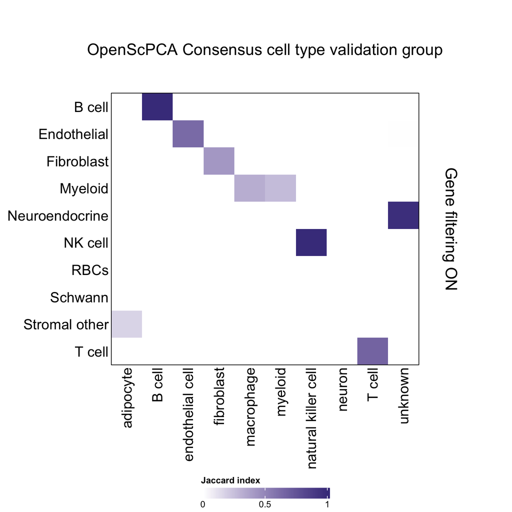

```r
make_jaccard_heatmap(
  singler_df,
  "validation_group_annotation",
  "singler_label_filtered",
  "OpenScPCA Consensus cell type validation group",
  "Gene filtering ON"
)
```

### Heatmap: Unfiltered vs. consensus annotations

This heatmap compares annotations between `SingleR` inference using the unfiltered reference and consensus cell types.

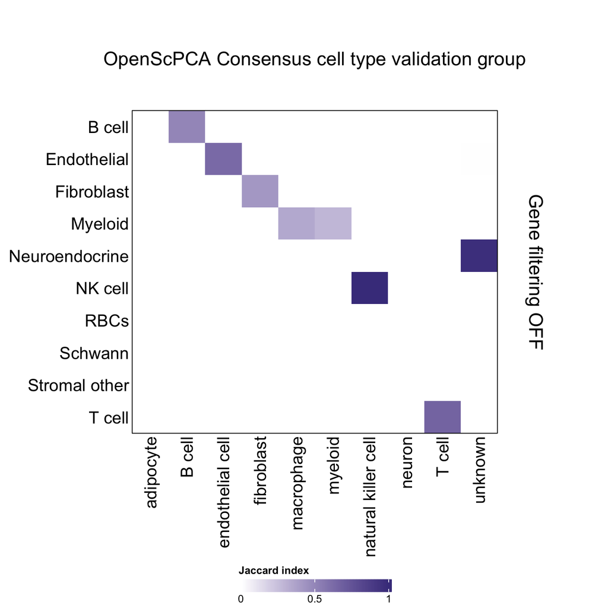

```r
make_jaccard_heatmap(
  singler_df,
  "validation_group_annotation",
  "singler_label_unfiltered",
  "OpenScPCA Consensus cell type validation group",
  "Gene filtering OFF"
)
```

## Compare trained SingleR models

In this section, we will compare the marker genes between filtered and unfiltered models. Output from this section will be same in all rendered notebooks since it is data-agnostic and focuses only on the trained SingleR models.

```r
filtered_markers <- model_filtered$markers$unique
unfiltered_markers <- model_unfiltered$markers$unique
```

First, are there any mitochondrial or ribosomal marker genes in the unfiltered model, and if so what are they?

```r
ribo_mito <- union(
  grep("^MT-", unfiltered_markers, value = TRUE),
  grep("^RP[SL]", unfiltered_markers, value = TRUE)
)
length(ribo_mito)
```

```
[1] 22
```

```r
ribo_mito
```

```
 [1] "RPL11"  "RPS8"   "RPS27"  "RPS27A" "RPL32"  "RPL34"  "RPS3A"  "RPS23"
 [9] "RPS18"  "RPS12"  "RPL39"  "RPL30"  "RPL8"   "RPS25"  "RPS29"  "RPLP1"
[17] "RPS15A" "RPL13"  "RPL18A" "RPS19"  "RPL28"  "RPL3"
```

[output not shown]

There are quite a few ribosomal genes, but no mitochondrial genes.

Which cell types do these marker genes come up for?

```r
model_unfiltered$markers$full |>
  purrr::map(
    \(inner_list) {
      purrr::reduce(inner_list, c)
    }
  ) |>
  purrr::map(
    \(all_marker_genes) {
      if (any(ribo_mito %in% all_marker_genes)) {
        intersect(ribo_mito, all_marker_genes)
      }
    }
  ) |>
  # remove all the NULLs
  purrr::compact()
```

```
$`B cell`
 [1] "RPL11"  "RPS27"  "RPS27A" "RPL34"  "RPS23"  "RPL39"  "RPL30"  "RPL8"
 [9] "RPS15A" "RPL13"  "RPL18A" "RPS19"  "RPL28"

$Fibroblast
[1] "RPS8"   "RPS27A"

$`NK cell`
[1] "RPS27"  "RPS15A"

$pDC
[1] "RPS3A" "RPS23" "RPS12"

$`T cell`
 [1] "RPL11"  "RPS8"   "RPS27"  "RPS27A" "RPL32"  "RPS18"  "RPS12"  "RPL39"
 [9] "RPL30"  "RPS25"  "RPS29"  "RPLP1"  "RPS15A" "RPL13"  "RPS19"  "RPL28"
[17] "RPL3"
```

[output not shown]

[output not shown]

[output not shown]

[output not shown]

[output not shown]

These marker genes are *only* associated with the following cell types, and of these predominantly B-cells and T-cells.

- B cells
- Fibroblasts
- Natural killer cells
- Plasmacytoid dendritic cells (pDCs)
- T cells

What genes do these models have in common, out of the total number of marker genes in each model?

- Total filtered markers:

```r
length(filtered_markers)
```

```
[1] 209
```

- Total unfiltered markers:

```r
length(unfiltered_markers)
```

```
[1] 222
```

- Number of intersecting markers:

```r
intersect(
  filtered_markers,
  unfiltered_markers
) |> length()
```

```
[1] 200
```

- Non-intersecting markers *aside from* ribosomal genes:

```r
diff_markers <- c(
  setdiff(filtered_markers, unfiltered_markers),
  setdiff(unfiltered_markers, filtered_markers)
)
diff_markers <- diff_markers[!(diff_markers %in% ribo_mito)]
diff_markers
```

```
[1] "RGS5"    "ZFP36L2" "IL7R"    "EEF1A1"  "FAU"     "BIRC3"   "CD3G"
[8] "JUNB"    "UBA52"
```

[output not shown]

There are nine different markers here. So, now that the ribosomal genes weren’t present to serve as markers, these genes were apparently picked up.

```r
any(diff_markers %in% filtered_markers)
```

```
[1] TRUE
```

```r
any(diff_markers %in% unfiltered_markers)
```

```
[1] FALSE
```

They are *all* part of the `filtered_markers` reference. Which cell type do those come up for?

```r
model_filtered$markers$full |>
  purrr::map(
    \(inner_list) {
      purrr::reduce(inner_list, c)
    }
  ) |>
  purrr::map(
    \(all_marker_genes) {
      if (any(diff_markers %in% all_marker_genes)) {
        intersect(diff_markers, all_marker_genes)
      }
    }
  ) |> # remove all the NULLs
  purrr::compact()
```

```
$`B cell`
[1] "FAU"   "BIRC3"

$Fibroblast
[1] "RGS5" "JUNB"

$`T cell`
[1] "ZFP36L2" "IL7R"    "EEF1A1"  "FAU"     "CD3G"    "JUNB"    "UBA52"
```

[output not shown]

[output not shown]

[output not shown]

They are in B-cells, Fibroblasts, and T-cells, all of which were cell types with ribosomal marker genes coming up in the unfiltered model.

### Conclusions from marker gene comparisons

- Filtering genes leads to ribosomal genes no longer being selected as marker genes in the trained model
- Ribosomal genes were most commonly observed as B-cell and T-cell marker genes
- Those ribosomal genes aside, the two models identified essentially the same overall marker genes